# Project overview - Understanding fish communities across nearshore habitats in southeast Alaska

Wendel Raymond

September 7, 2018

# Understanding fish communities across nearshore habitats

author: Wendel Raymond  
date: 9/18/2018 font-family: ‘Helvetica’

# Goals and Objectives

- Goal
  - Understand fish community composition across nearshore habitats in southeast Alaska
- Objectives
  1. Build a statistical model to relate community structure (multivariate) to habitat characteristics
  2. Build a statistical model to relate juvenile abundance of harvested species/groups (e.g. Salmonidae, Gadidae) to habitat characteristics

# Background - Data

- Atlas of Nearshore Fishes of Alaska + 1998 - 2011 + 555 unique sites + Walleye pollock, Pacific herring, pink salmon, and chum salmon accounted for 55% of total catch

- Habitats
  - Bedrock
  - Eelgrass (Seagrass)
  - Understory kelp
  - Sand / Gravel

[figure not shown]

# Background - Analyses

- Previous Analyses
  - NOAA technical memoranda and a few peer-reviewed papers
  - Summary statistics, small geographic scale
  - Fish community appears to differ across habitats
- Data analysis in community ecology class project
  - Began to tackle this question of community composition as a function of habitat
  - Results later

# Data

- Explanatory
  - Site information (region, sub-region, locale)
  - Lat/Long
  - Temp/Salinity
  - Gear Type
  - Date
  - Habitat

# Data

- Response
  - Species
  - Life Stage
  - Fork Length (FL)
  - Count of unmeasured fish

# Data

[interactive chart not shown]

# Data

[interactive chart not shown]

# Proposed data processing

The data *may* need some work before its ready for full analysis.

1. Assign unmeasured fish FL based off the population* sample
2. Convert FL to mass
3. Append/have full taxonomic information ready for each species
- To group at higher taxonomic levels

# Previous modeling approaches

Tested for the effect of Habitat on fish community composition

- Habitat only
- Counts

$$fish community (counts) = Habitat$$

PERMANOVA results indicated that fish community composition was significantly different among habitats (psudo-F = 17.04, p-value < 0.001).

# Previous modeling approaches

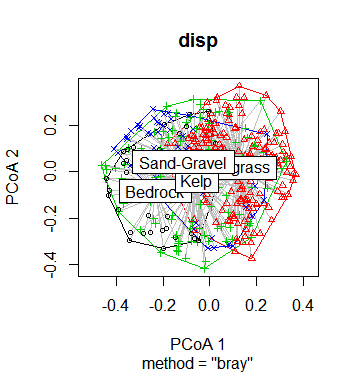

# Proposed approach

1. Build a statistical model to relate community structure (multivariate) to habitat characteristics

$$fish community = Habitat + time + ....$$

2. Build a statistical model to relate juvenile abundance of harvested species/groups (e.g. Salmonidae, Gadidae) to habitat characteristics

$$Salmonidae = Habitat + time + ....$$

# Things to work on

$$fish community = Habitat + time + ....$$

$$Salmonidae = Habitat + time + ....$$

- What should the response really be?
  - counts? - probably not, masks hugh variation in size and abundance
  - mass?
  - remove rare species? - what counts as rare?
- What factors should be in the global model?
  - Habitat + time*
  - Location (Lat/Long, sub-region)?
  - Temp, salinity?
  - Distance to anadromous stream?
  - Distance to salmon hatchery release site?

# Things to work on

Multivariate analysis - Response will need to be examined for normality

- Transform and standardize

# Work flow

- GitHub

[figure not shown]